# Solución

Evaluación - Regresión Logística

Diplomado en Data Science UC

El archivo *rrhh.csv* contiene información de la situación laboral de los trabajadores de la empresa ABAC. Las variables disponibles son:

- **Estado**: Estado actual del trabajador en la empresa (1: desvinculado, 0: vinculado).
- **Edad**: Edad del trabajador en años.
- **Ratio.Pago**: Medida de pago por hora (numérico).
- **Salario**: Salario mensual en dólares que tiene o tenía el trabajador.
- **Dias.trabajados**: Días que lleva o llevaba trabajando en la empresa.
- **Ausencias**: Días que ha faltado a trabajar.
- **Sexo**: Sexo del trabajador (Female , Male).
- **Estado.Civil**: Estado civil del trabajador (1: divorciado, 2: casado,3: separado, 4: soltero, 5: viuda).
- **Departamento**: Lugar de trabajo en la empresa (Admin Offices,..).
- **Posicion**: Cargo del trabajador/empleado (Accountant I ,…. ).
- **Desempeño**: Clasificación del desempeño del trabajador.

### Carga, limpieza y formato de los datos

1. Cargue los datos en R y revise los formatos de cada variable, recuerde codificar las variables como numéricas o factores según corresponda.

#### **Solución**

```r
### Lectura base de datos
data <- readr::read_csv("rrhh.csv")

### Revision de estructura de la base
dplyr::glimpse(data)
```

```
## Rows: 310
## Columns: 11
## $ Estado          <dbl> 0, 0, 0, 0, 0, 1, 0, 1, 0, 0, 0, 0, 1, 1, 1, 0, 1, 0, ~
## $ Edad            <dbl> 30, 34, 31, 32, 30, 30, 33, 33, 31, 39, 63, 38, 32, 46~
## $ Ratio.Pago      <dbl> 28.50, 23.00, 29.00, 21.50, 16.56, 20.50, 55.00, 55.00~
## $ Salario         <dbl> 4167.067, 6962.467, 4330.333, 4332.733, 3388.333, 3837~
## $ Dias.trabajados <dbl> 3317, 1420, 1154, 58, 940, 730, 691, 1636, 1014, 3247,~
## $ Ausencias       <dbl> 1, 17, 3, 15, 2, 15, 19, 19, 4, 16, 12, 15, 9, 7, 1, 2~
## $ Sexo            <chr> "Female", "Male", "Male", "Female", "Female", "Female"~
## $ Estado.Civil    <dbl> 2, 1, 4, 2, 4, 2, 2, 2, 2, 2, 2, 4, 4, 4, 2, 4, 2, 1, ~
## $ Departamento    <chr> "Admin Offices", "Admin Offices", "Admin Offices", "Ad~
## $ Posicion        <chr> "Accountant I", "Accountant I", "Accountant I", "Admin~
## $ Desempeño       <chr> "Fully Meets", "Fully Meets", "Fully Meets", "N/A- too~
```

La variable Estado.Civil es considerada numerica. Se tranforma a categórica por conveniencia. Además, se transforman las variables de tipo caracter a factor.

```r
data <- data %>%
  dplyr::mutate(Estado.Civil = case_when(Estado.Civil == 1 ~ "Divorciado",
                                         Estado.Civil == 2 ~ "Casado",
                                         Estado.Civil == 3 ~ "Separado",
                                         Estado.Civil == 4 ~ "Soltero",
                                         Estado.Civil == 5 ~ "Viudo/a",
                                         TRUE ~ NA_character_))

### Cambiar variables caracter a factor

data <- data %>%
  dplyr::mutate_if(is.character, as.factor)

### Revisar estructura
dplyr::glimpse(data)
```

```
## Rows: 310
## Columns: 11
## $ Estado          <dbl> 0, 0, 0, 0, 0, 1, 0, 1, 0, 0, 0, 0, 1, 1, 1, 0, 1, 0, ~
## $ Edad            <dbl> 30, 34, 31, 32, 30, 30, 33, 33, 31, 39, 63, 38, 32, 46~
## $ Ratio.Pago      <dbl> 28.50, 23.00, 29.00, 21.50, 16.56, 20.50, 55.00, 55.00~
## $ Salario         <dbl> 4167.067, 6962.467, 4330.333, 4332.733, 3388.333, 3837~
## $ Dias.trabajados <dbl> 3317, 1420, 1154, 58, 940, 730, 691, 1636, 1014, 3247,~
## $ Ausencias       <dbl> 1, 17, 3, 15, 2, 15, 19, 19, 4, 16, 12, 15, 9, 7, 1, 2~
## $ Sexo            <fct> Female, Male, Male, Female, Female, Female, Male, Male~
## $ Estado.Civil    <fct> Casado, Divorciado, Soltero, Casado, Soltero, Casado, ~
## $ Departamento    <fct> Admin Offices, Admin Offices, Admin Offices, Admin Off~
## $ Posicion        <fct> Accountant I, Accountant I, Accountant I, Administrati~
## $ Desempeño       <fct> Fully Meets, Fully Meets, Fully Meets, N/A- too early ~
```

### Análisis descriptivo y exploratorio de datos

2. Realice un análisis descriptivo de sus datos. Determinar si existen observaciones faltantes, en el caso de existir tome la decisión de omitirlas del estudio u omitir la variable. Evalúe si existen posibles incongruencias en la fuente de datos (ej: edades negativas). Y finalmente análice la presencia de valores atípicos en las variables. Comente.

#### **Solución**

```r
skimr::skim(data)
```

Data summary

| Name | data |
| --- | --- |
| Number of rows | 310 |
| Number of columns | 11 |
| _______________________ |  |
| Column type frequency: |  |
| factor | 5 |
| numeric | 6 |
| ________________________ |  |
| Group variables | None |

**Variable type: factor**

| skim_variable | n_missing | complete_rate | ordered | n_unique | top_counts |
| --- | --- | --- | --- | --- | --- |
| Sexo | 0 | 1 | FALSE | 2 | Fem: 177, Mal: 133 |
| Estado.Civil | 0 | 1 | FALSE | 5 | Sol: 137, Cas: 123, Div: 30, Sep: 12 |
| Departamento | 0 | 1 | FALSE | 6 | Pro: 208, IT/: 50, Sal: 31, Adm: 10 |
| Posicion | 0 | 1 | FALSE | 28 | Pro: 136, Pro: 57, Are: 27, Pro: 14 |
| Desempeño | 0 | 1 | FALSE | 7 | Ful: 181, N/A: 37, 90-: 31, Exc: 28 |

**Variable type: numeric**

| skim_variable | n_missing | complete_rate | mean | sd | p0 | p25 | p50 | p75 | p100 | hist |
| --- | --- | --- | --- | --- | --- | --- | --- | --- | --- | --- |
| Estado | 0 | 1 | 0.41 | 0.49 | 0.0 | 0.00 | 0.00 | 1.00 | 1.00 | ▇▁▁▁▆ |
| Edad | 0 | 1 | 38.87 | 8.92 | 25.0 | 32.00 | 37.00 | 44.00 | 67.00 | ▇▇▅▂▁ |
| Ratio.Pago | 0 | 1 | 31.28 | 15.38 | 14.0 | 20.00 | 24.00 | 45.31 | 80.00 | ▇▂▂▂▁ |
| Salario | 0 | 1 | 4606.53 | 1677.35 | 3004.6 | 3707.03 | 4190.67 | 4804.73 | 16666.67 | ▇▁▁▁▁ |
| Dias.trabajados | 0 | 1 | 1296.08 | 769.49 | 2.0 | 766.25 | 1238.00 | 1732.75 | 4339.00 | ▅▇▃▁▁ |
| Ausencias | 0 | 1 | 10.26 | 5.84 | 1.0 | 5.00 | 10.00 | 15.00 | 20.00 | ▇▆▅▇▆ |

```r
summary(data)
```

```
##      Estado            Edad         Ratio.Pago       Salario
##  Min.   :0.0000   Min.   :25.00   Min.   :14.00   Min.   : 3005
##  1st Qu.:0.0000   1st Qu.:32.00   1st Qu.:20.00   1st Qu.: 3707
##  Median :0.0000   Median :37.00   Median :24.00   Median : 4191
##  Mean   :0.4097   Mean   :38.87   Mean   :31.28   Mean   : 4607
##  3rd Qu.:1.0000   3rd Qu.:44.00   3rd Qu.:45.31   3rd Qu.: 4805
##  Max.   :1.0000   Max.   :67.00   Max.   :80.00   Max.   :16667
##
##  Dias.trabajados    Ausencias         Sexo         Estado.Civil
##  Min.   :   2.0   Min.   : 1.00   Female:177   Casado    :123
##  1st Qu.: 766.2   1st Qu.: 5.00   Male  :133   Divorciado: 30
##  Median :1238.0   Median :10.00                Separado  : 12
##  Mean   :1296.1   Mean   :10.26                Soltero   :137
##  3rd Qu.:1732.8   3rd Qu.:15.00                Viudo/a   :  8
##  Max.   :4339.0   Max.   :20.00
##
##                Departamento                     Posicion
##  Admin Offices       : 10   Production Technician I :136
##  Executive Office    :  1   Production Technician II: 57
##  IT/IS               : 50   Area Sales Manager      : 27
##  Production          :208   Production Manager      : 14
##  Sales               : 31   Database Administrator  : 13
##  Software Engineering: 10   Network Engineer        :  9
##                             (Other)                 : 54
##                     Desempeño
##  90-day meets            : 31
##  Exceeds                 : 28
##  Exceptional             :  9
##  Fully Meets             :181
##  N/A- too early to review: 37
##  Needs Improvement       : 15
##  PIP                     :  9
```

No existen incongruencias ni datos faltantes. Se utilizará la data completa.

3. Realice análisis de cómo se relacionan las variables **continuas** con la variable de interés. Acompañe con gráficos y estadísticas. ¿Qué variables pudieran resultar significativas a la hora de modelar la probabilidad de que el trabajador sea desvinculado a la empresa?

#### **Solución**

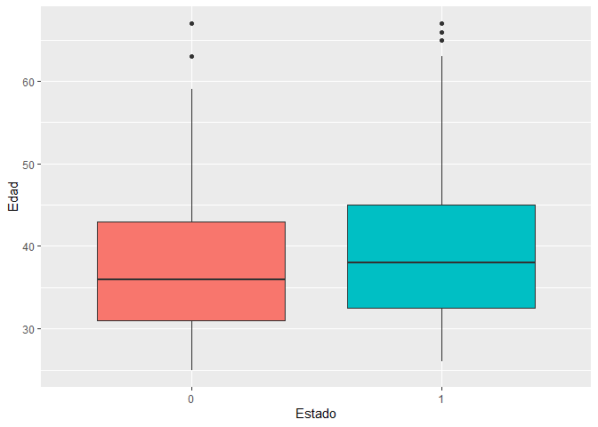

```r
### Edad
ggplot(data = data, mapping = aes(x = factor(Estado), y = Edad, fill = factor(Estado))) +
  geom_boxplot() + theme(legend.position = "none") + labs(x = "Estado")
```

```r
anova(aov(Edad ~ factor(Estado), data = data))
```

```
## Analysis of Variance Table
##
## Response: Edad
##                 Df Sum Sq Mean Sq F value  Pr(>F)
## factor(Estado)   1    272 271.984  3.4435 0.06446 .
## Residuals      308  24328  78.986
## ---
## Signif. codes:  0 '***' 0.001 '**' 0.01 '*' 0.05 '.' 0.1 ' ' 1
```

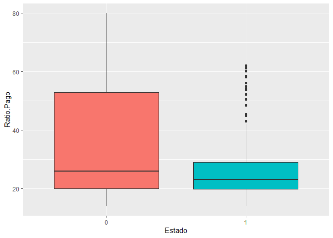

```r
### Ratio.Pago

ggplot(data = data, mapping = aes(x = factor(Estado), y = Ratio.Pago, fill = factor(Estado))) +
  geom_boxplot() + theme(legend.position = "none") + labs(x = "Estado")
```

```r
anova(aov(Ratio.Pago ~ factor(Estado), data = data))
```

```
## Analysis of Variance Table
##
## Response: Ratio.Pago
##                 Df Sum Sq Mean Sq F value    Pr(>F)
## factor(Estado)   1   2907 2907.12  12.751 0.0004126 ***
## Residuals      308  70219  227.99
## ---
## Signif. codes:  0 '***' 0.001 '**' 0.01 '*' 0.05 '.' 0.1 ' ' 1
```

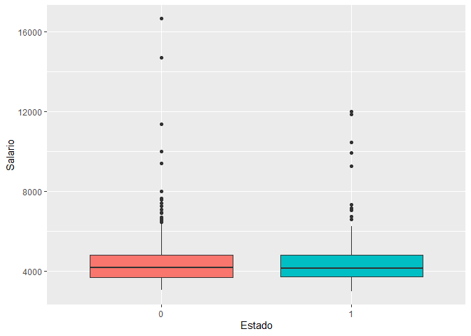

```r
### Salario

ggplot(data = data, mapping = aes(x = factor(Estado), y = Salario, fill = factor(Estado))) +
  geom_boxplot() + theme(legend.position = "none") + labs(x = "Estado")
```

```r
anova(aov(Salario ~ factor(Estado), data = data))
```

```
## Analysis of Variance Table
##
## Response: Salario
##                 Df    Sum Sq Mean Sq F value Pr(>F)
## factor(Estado)   1     61134   61134  0.0217 0.8831
## Residuals      308 869311482 2822440
```

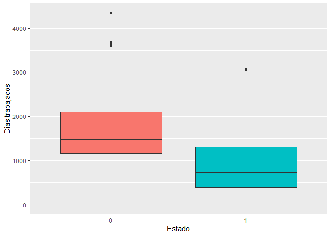

```r
### Dias.trabajados

ggplot(data = data, mapping = aes(x = factor(Estado), y = Dias.trabajados, fill = factor(Estado))) +
  geom_boxplot() + theme(legend.position = "none") + labs(x = "Estado")
```

```r
anova(aov(Dias.trabajados ~ factor(Estado), data = data))
```

```
## Analysis of Variance Table
##
## Response: Dias.trabajados
##                 Df    Sum Sq  Mean Sq F value    Pr(>F)
## factor(Estado)   1  44824671 44824671  99.942 < 2.2e-16 ***
## Residuals      308 138139478   448505
## ---
## Signif. codes:  0 '***' 0.001 '**' 0.01 '*' 0.05 '.' 0.1 ' ' 1
```

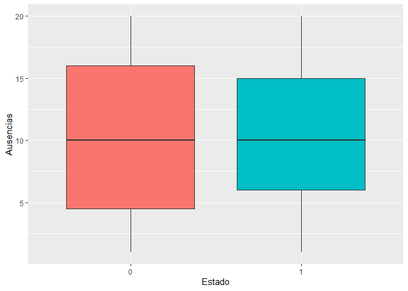

```r
### Ausencias

ggplot(data = data, mapping = aes(x = factor(Estado), y = Ausencias, fill = factor(Estado))) +
  geom_boxplot() + theme(legend.position = "none") + labs(x = "Estado")
```

```r
anova(aov(Ausencias ~ factor(Estado), data = data))
```

```
## Analysis of Variance Table
##
## Response: Ausencias
##                 Df  Sum Sq Mean Sq F value Pr(>F)
## factor(Estado)   1     0.4   0.390  0.0114 0.9151
## Residuals      308 10549.9  34.253
```

Al parecer, las variables que podrian estar influyendo en la desvinculacion de un trabajador es Ratio.Pago y Dias.trabajados.

4. Realice análisis de cómo se relacionan las variables **categóricas** con la variable de interés. Acompañe con gráficos y estadísticas. ¿Qué variables pudieran resultar significativas a la hora de modelar la probabilidad de que el trabajador sea desvinculado a la empresa?

#### **Solución**

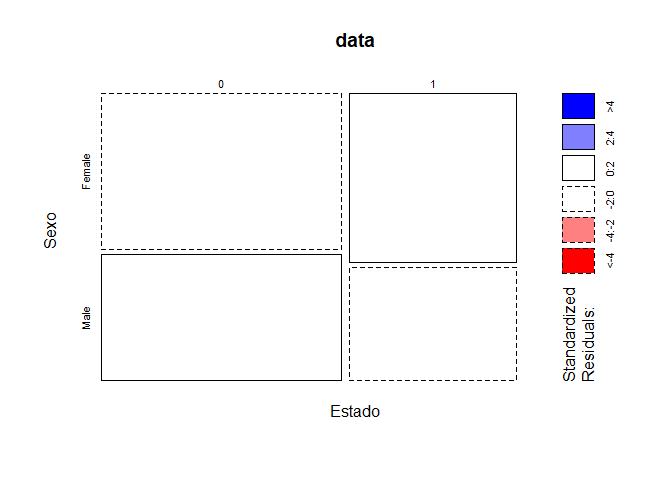

```r
### Sexo
### Opcion 1: Hacer un grafico con mosaicplot
mosaicplot(~Estado + Sexo, data = data, shade = TRUE)
```

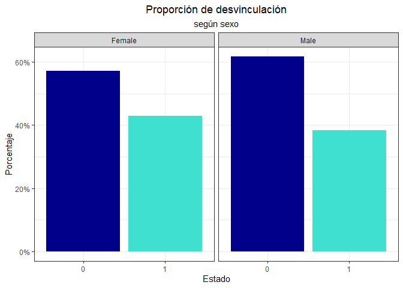

```r
### Opcion 2: Hacer un grafico como la actividad de graficos
ggplot(data = data, aes(x = factor(Estado),
                        y = ..prop..,
                        group = Sexo,
                        fill = factor(..x..))) +
  geom_bar(position = "dodge") +
  labs(title = "Proporción de desvinculación",
       subtitle = "según sexo",
       x = "Estado", y = "Porcentaje") +
  scale_y_continuous(labels = scales::percent) +
  theme_bw() +
  theme(plot.title = element_text(hjust = 0.5),
        plot.subtitle = element_text(hjust = 0.5),
        legend.position = "none") +
  scale_fill_manual(values = c("darkblue", "turquoise")) +
  facet_grid(~Sexo)
```

```r
chisq.test(factor(data$Estado), data$Sexo)
```

```
##
##  Pearson's Chi-squared test with Yates' continuity correction
##
## data:  factor(data$Estado) and data$Sexo
## X-squared = 0.48585, df = 1, p-value = 0.4858
```

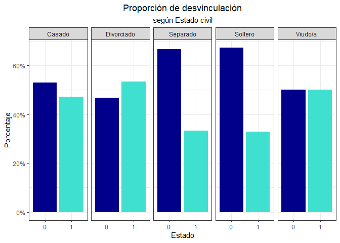

```r
### Estado.Civil

ggplot(data = data, aes(x = factor(Estado),
                        y = ..prop..,
                        group = Estado.Civil,
                        fill = factor(..x..))) +
  geom_bar(position = "dodge") +
  labs(title = "Proporción de desvinculación",
       subtitle = "según Estado civil",
       x = "Estado", y = "Porcentaje") +
  scale_y_continuous(labels = scales::percent) +
  theme_bw() +
  theme(plot.title = element_text(hjust = 0.5),
        plot.subtitle = element_text(hjust = 0.5),
        legend.position = "none") +
  scale_fill_manual(values = c("darkblue", "turquoise")) +
  facet_grid(~Estado.Civil)
```

```r
chisq.test(factor(data$Estado), data$Estado.Civil)
```

```
##
##  Pearson's Chi-squared test
##
## data:  factor(data$Estado) and data$Estado.Civil
## X-squared = 8.1386, df = 4, p-value = 0.08663
```

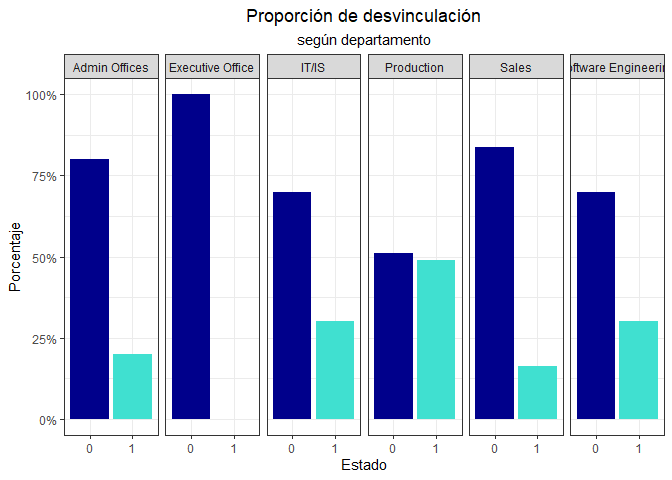

```r
### Departamento

ggplot(data = data, aes(x = factor(Estado),
                        y = ..prop..,
                        group = Departamento,
                        fill = factor(..x..))) +
  geom_bar(position = "dodge") +
  labs(title = "Proporción de desvinculación",
       subtitle = "según departamento",
       x = "Estado", y = "Porcentaje") +
  scale_y_continuous(labels = scales::percent) +
  theme_bw() +
  theme(plot.title = element_text(hjust = 0.5),
        plot.subtitle = element_text(hjust = 0.5),
        legend.position = "none") +
  scale_fill_manual(values = c("darkblue", "turquoise")) +
  facet_grid(~Departamento)
```

```r
chisq.test(factor(data$Estado), data$Departamento)
```

```
##
##  Pearson's Chi-squared test
##
## data:  factor(data$Estado) and data$Departamento
## X-squared = 19.007, df = 5, p-value = 0.001917
```

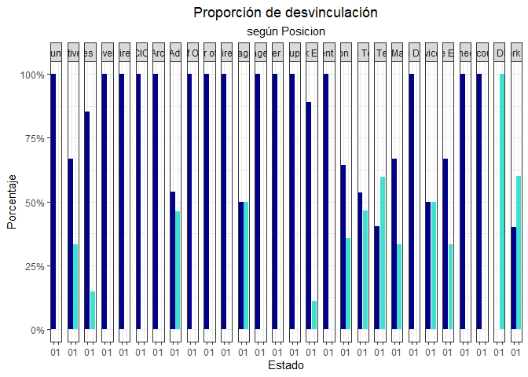

```r
### Posicion

ggplot(data = data, aes(x = factor(Estado),
                        y = ..prop..,
                        group = Posicion,
                        fill = factor(..x..))) +
  geom_bar(position = "dodge") +
  labs(title = "Proporción de desvinculación",
       subtitle = "según Posicion",
       x = "Estado", y = "Porcentaje") +
  scale_y_continuous(labels = scales::percent) +
  theme_bw() +
  theme(plot.title = element_text(hjust = 0.5),
        plot.subtitle = element_text(hjust = 0.5),
        legend.position = "none") +
  scale_fill_manual(values = c("darkblue", "turquoise")) +
  facet_grid(~Posicion)
```

```r
chisq.test(factor(data$Estado), data$Posicion)
```

```
##
##  Pearson's Chi-squared test
##
## data:  factor(data$Estado) and data$Posicion
## X-squared = 46.149, df = 27, p-value = 0.01226
```

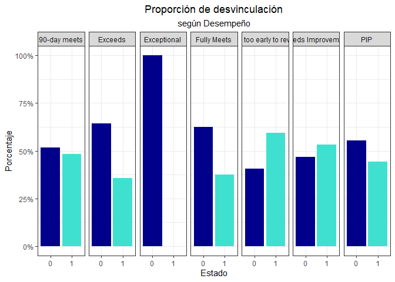

```r
### Desempeño

ggplot(data = data, aes(x = factor(Estado),
                        y = ..prop..,
                        group = `Desempeño`,
                        fill = factor(..x..))) +
  geom_bar(position = "dodge") +
  labs(title = "Proporción de desvinculación",
       subtitle = "según Desempeño",
       x = "Estado", y = "Porcentaje") +
  scale_y_continuous(labels = scales::percent) +
  theme_bw() +
  theme(plot.title = element_text(hjust = 0.5),
        plot.subtitle = element_text(hjust = 0.5),
        legend.position = "none") +
  scale_fill_manual(values = c("darkblue", "turquoise")) +
  facet_grid(~`Desempeño`)
```

```r
chisq.test(factor(data$Estado), data$Desempeño)
```

```
##
##  Pearson's Chi-squared test
##
## data:  factor(data$Estado) and data$Desempeño
## X-squared = 14.36, df = 6, p-value = 0.02586
```

### Modelamiento

5. Realice una separación de la base de datos en un set de entrenamiento y set de validación, utilice una proporción de 75:25 respectivamente. Para poder replicar sus resultados, fije una semilla antes de obtener los indices. Para ello, utilice la función set.seed(2021).

#### **Solución**

```r
set.seed(2021)
indice <- sample(x = 1:nrow(data), size = 0.75*nrow(data), replace = FALSE)

data_train <- data %>%
  dplyr::slice(indice)

data_test <- data %>%
  dplyr::slice(-indice)
```

6. Con los datos de entrenamiento ajuste un modelo de regresión logística para estudiar la probabilidad de que el trabajador sea desvinculado de la empresa. Para ello, utilice las variables edad y desempeño.

#### **Solución**

```r
modelo1 <- glm(Estado ~ Edad + Desempeño, data = data_train,
               family = binomial(link = "logit"))

summary(modelo1)
```

```
##
## Call:
## glm(formula = Estado ~ Edad + Desempeño, family = binomial(link = "logit"),
##     data = data_train)
##
## Deviance Residuals:
##     Min       1Q   Median       3Q      Max
## -1.6754  -0.9672  -0.7688   1.1903   1.8741
##
## Coefficients:
##                                     Estimate Std. Error z value Pr(>|z|)
## (Intercept)                         -1.73355    0.74664  -2.322  0.02024 *
## Edad                                 0.05007    0.01647   3.039  0.00237 **
## DesempeñoExceeds                    -1.38505    0.68098  -2.034  0.04196 *
## DesempeñoExceptional               -16.78511 1058.55891  -0.016  0.98735
## DesempeñoFully Meets                -0.78597    0.45760  -1.718  0.08587 .
## DesempeñoN/A- too early to review    0.40178    0.56572   0.710  0.47757
## DesempeñoNeeds Improvement          -0.22693    0.74007  -0.307  0.75913
## DesempeñoPIP                        -0.41360    0.88193  -0.469  0.63909
## ---
## Signif. codes:  0 '***' 0.001 '**' 0.01 '*' 0.05 '.' 0.1 ' ' 1
##
## (Dispersion parameter for binomial family taken to be 1)
##
##     Null deviance: 313.97  on 231  degrees of freedom
## Residual deviance: 290.26  on 224  degrees of freedom
## AIC: 306.26
##
## Number of Fisher Scoring iterations: 15
```

7. Calcule e interprete los OR correspondientes al modelo, ¿son estos factores protectores o agravantes de la desvinculación del trabajador?

#### **Solución**

```r
### Se crea una data con los nombres de las variables del modelo
### (se elimina la primera categoria de desempeño, ya que es la de referencia).
### Se elimina además el OR del primer coeficiente, ya que representa el intercepto.
options(scipen = 999)

data.frame(Variables = c("Edad", levels(data$Desempeño)[-1]),
           OR = round(as.vector(exp(modelo1$coefficients)[-1]), 2))
```

```
##                  Variables   OR
## 1                     Edad 1.05
## 2                  Exceeds 0.25
## 3              Exceptional 0.00
## 4              Fully Meets 0.46
## 5 N/A- too early to review 1.49
## 6        Needs Improvement 0.80
## 7                      PIP 0.66
```

Todos aquellas variables o categorías con OR por sobre 1, son agravantes de la desvinculación de un trabajador. En este caso, el OR de la variable Edad tiene un 5% de aumento de la chance cuando la edad aumenta en un año. Además, la chance de desvinculación aumenta en un casi 50% cuando el desempeño es de tipo `N/A- too early to review` en comparación a 90-day meets.

8. Utilizando un método automatizado, encuentre el modelo óptimo usando como criterio el criterio de información de Akaike (AIC). La función step() puede ser de utilidad.

#### **Solución**

El resultado final, dependerá de la metodología que escoja el alumno.

```r
modelo_completo <- glm(Estado ~ ., data = data_train,
                       family = binomial(link = "logit"))

modelo_simple <- glm(Estado ~ 1, data = data_train,
                     family = binomial(link = "logit"))

### Opción backward

modelo_backward <- step(modelo_completo,
                        direction = "backward",
                        trace = FALSE)

formula(modelo_backward)
```

```
## Estado ~ Edad + Ratio.Pago + Dias.trabajados
```

```r
### Opción forward

modelo_forward <- step(modelo_simple,
                       direction = "forward",
                       scope = list(upper = modelo_completo,
                                    lower = modelo_simple),
                       trace = FALSE)

formula(modelo_forward)
```

```
## Estado ~ Dias.trabajados + Departamento + Edad
```

```r
### Se compara AIC entre los dos
AIC(modelo_backward, modelo_forward)
```

```
##                 df      AIC
## modelo_backward  4 225.5700
## modelo_forward   7 226.8451
```

```r
### Se escoje el modelo backward.
```

1. Si usted trabaja en la empresa ABAC, calcule su probabilidad de ser desvinculado. Suponga que sus características son:
- Edad: 34
- Ratio.Pago: 34.95
- Salario: 3345.2
- Dias.trabajados: 3247
- Ausencias: 16
- Sexo: Female
- Estado.Civil: 2
- Departamento: Admin Offices
- Posicion: Sr. Accountant
- Desempeño: Fully Meets

#### **Solución**

```r
### Se crea la data con los datos entregados.

data_new <- data.frame(Edad = 34,
                       Ratio.Pago = 34.95,
                       Salario = 3345.2,
                       Dias.trabajados = 3247,
                       Ausencias = 16,
                       Sexo = "Female",
                       Estado.Civil = "Casado",
                       Departamento = "Admin Offices",
                       Posicion = "Sr. Accountant",
                       Desempeño = "Fully Meets")

### En caso de que el modelo haya sido por backward

predict.glm(modelo_backward, newdata = data_new, type = "response")
```

```
##           1
## 0.004205649
```

La probabilidad de ser desvinculado es de aproximadamente 0%.

### Validación del modelo

10. Utilizando la base de validación y el modelo obtenido en la pregunta anterior, calcule las probabilidades de que el trabajador sea desvinculado.

#### **Solución**

```r
### En caso de que el modelo haya sido por backward
predicciones <- predict.glm(modelo_backward, newdata = data_test, type = "response")
```

11. Identifique el punto de corte que optimice la sensibilidad del modelo, pero que cometa como máximo una tasa de falsos positivos (1 - Especificidad) de a lo más un 25%. Use el argumento `returnSensitivityMat = TRUE` en la función `plotROC()`. Y obtenga las matrices de confusión y los indicadores de:
- Sensibilidad
- Especificidad
- Precisión

#### **Solución**

```r
### Calculo de punto de corte
corte <- InformationValue::optimalCutoff(data_test$Estado, predicciones)
corte
```

```
## [1] 0.5632297
```

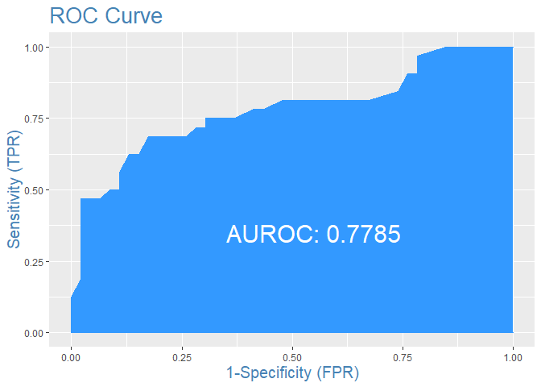

```
##    One_minus_specificity sensitivity Threshold
## 1             0.00000000     0.00000      1.00
## 2             0.00000000     0.00000      0.98
## 3             0.00000000     0.03125      0.96
## 4             0.00000000     0.06250      0.94
## 5             0.00000000     0.06250      0.92
## 6             0.00000000     0.12500      0.90
## 7             0.02173913     0.18750      0.88
## 8             0.02173913     0.21875      0.86
## 9             0.02173913     0.31250      0.84
## 10            0.02173913     0.31250      0.82
## 11            0.02173913     0.34375      0.80
## 12            0.02173913     0.43750      0.78
## 13            0.02173913     0.43750      0.76
## 14            0.02173913     0.46875      0.74
```

[output cut: 38 more lines]

```r
### Grafico de la curva ROC

InformationValue::plotROC(data_test$Estado, predicciones, returnSensitivityMat = TRUE)
```

```r
### Calculo de la matriz de confusion

InformationValue::confusionMatrix(data_test$Estado, predicciones, corte)
```

```
##    0  1
## 0 38 10
## 1  8 22
```

```r
### Calculo de sensibilidad
InformationValue::sensitivity(data_test$Estado, predicciones, corte)
```

```
## [1] 0.6875
```

```r
### Calculo de especificidad

InformationValue::specificity(data_test$Estado, predicciones, corte)
```

```
## [1] 0.826087
```

```r
### Calculo de precision

InformationValue::precision(data_test$Estado, predicciones, corte)
```

```
## [1] 0.7333333
```

12. Evalúe el modelo y concluya. Para ello, obtenga e interprete los siguientes estadísticos:
- Área bajo la curva ROC
- Test de Kolmogorov - Smirnov (*Hint: utilice la `función ks.test(x, y)`* ).
- Test de Hosmer - Lemeshow (*Hint: utilice la función `ResourceSelection::hoslem.test()`* ).

#### **Solución**

```r
### Calculo del area bajo la curva

InformationValue::AUROC(data_test$Estado, predicciones)
```

```
## [1] 0.7785326
```

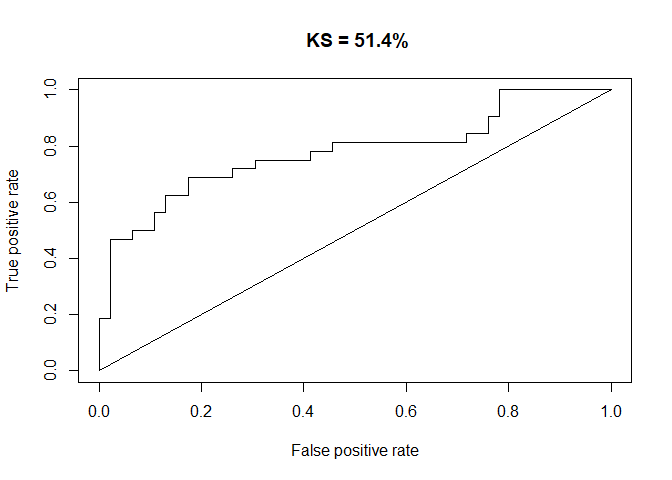

```r
### Calculo del estadistico KS
library(ROCR)

### Convertimos los datos en un objeto "prediction" para ser utilizado con el
### package ROCR
pred <- prediction(predicciones, data_test$Estado)

### Rescatamos la distribucion de los verdaderos positivos junto con los
### falsos positivos.

perf <- performance(pred, "tpr", "fpr")

### Se calcula la diferencia máxima entre el verdadero positivo acumulado
### y el falso acumulado
ks = max(attr(perf,'y.values')[[1]] - attr(perf,'x.values')[[1]])

### Se grafica la curva ROC
plot(perf, main = paste0(' KS = ', round(ks*100,1),'%'))
lines(x = c(0,1), y = c(0,1))
```

```r
print(ks)
```

```
## [1] 0.513587
```

```r
### Calculo del test de Hosmer Lemeshow
#### Se calcula el test tanto para el caso de entrenamiento como de test.
ResourceSelection::hoslem.test(data_train$Estado,
                               fitted(modelo_backward))$p.value
```

```
## [1] 0.1235493
```

```r
ResourceSelection::hoslem.test(data_test$Estado,
                               predict(modelo_backward, newdata = data_test, type = "response"))$p.value
```

```
## [1] 0.00001194848
```

#### Tabla resumen

```r
Resumen <- data.frame(Sensibilidad = InformationValue::sensitivity(data_test$Estado, predicciones, corte),
                      Especificidad = InformationValue::specificity(data_test$Estado, predicciones, corte),
                      Precision = InformationValue::precision(data_test$Estado, predicciones, corte),
                      AUC = InformationValue::AUROC(data_test$Estado, predicciones),
                      KS = ks,
                      HosmerLemeshow = ResourceSelection::hoslem.test(data_test$Estado,
                               predict(modelo_backward, newdata = data_test))$p.value)

knitr::kable(Resumen, digits = 2)
```

| Sensibilidad | Especificidad | Precision | AUC | KS | HosmerLemeshow |
| --- | --- | --- | --- | --- | --- |
| 0.69 | 0.83 | 0.73 | 0.78 | 0.51 | 1 |